Produced Wednesday 30 December 2020

**This is one page of the R Handbook for Epidemiologists, but is being printed as a stand-alone page.**

**You can find the complete handbook on [Github](https://github.com/nsbatra/Epi_R_handbook)**

# Cleaning data

## Overview

This page demonstrates common steps necessary to clean a dataset. It uses a simulated Ebola case linelist, which is used throughout the handbook.

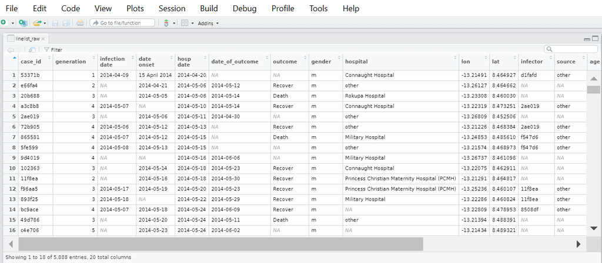

- Dealing with character case (upper, lower, title, etc.)
- Factor columns

## Preparation

## Preparation

### Load packages

```r
pacman::p_load(tidyverse,  # data manipulation and visualization
               janitor,    # data cleaning
               rio,        # importing data
               epikit)     # age_categories() function
```

### Load data

Import the raw dataset using the `import()` function from the package **rio**. (LINK HERE TO IMPORT PAGE)

```r
linelist_raw <- import("linelist_raw.xlsx")
```

You can view the first 50 rows of the the original “raw” dataset below:

| row_num | case_id | generation | infection date | date onset | hosp date | date_of_outcome | outcome | gender | hospital | lon | lat | infector | source | age | age_unit | fever | chills | cough | aches | vomit | time_admission | merged_header | ...24 |
| --- | --- | --- | --- | --- | --- | --- | --- | --- | --- | --- | --- | --- | --- | --- | --- | --- | --- | --- | --- | --- | --- | --- | --- |
| 1 | 53371b | 1 | 2014-04-09T00:00:00Z | 15th April 2014 | 2014-04-20T00:00:00Z |  |  | m | Port Hospital | -13.2149052395664 | 8.46492652251777 | d1fafd | other | 12 | years | yes | no | yes | no | yes | 09:25 | under a merged header | under a merged header |
| 2 | e66fa4 | 2 |  | 2014-04-21 | 2014-05-06T00:00:00Z | 2014-05-12T00:00:00Z | Recover | m | Other | -13.2612684289806 | 8.46466205027363 |  |  | 10 | years | no | no | yes | no | yes | 14:36 | under a merged header | under a merged header |
| 3 | 20b688 | 3 |  | 2014-05-05 | 2014-05-06T00:00:00Z | 2014-05-14T00:00:00Z | Death | m | Central Hospital | -13.2330769474001 | 8.46002984141364 |  |  | 10 | years | no | no | yes | no | yes | 18:42 | under a merged header | under a merged header |
| 4 | a3c8b8 | 4 | 2014-05-07T00:00:00Z | 2014-05-08 | 2014-05-10T00:00:00Z | 2014-05-14T00:00:00Z | Recover | m | Port Hospital | -13.2231931914572 | 8.47325128269697 | 2ae019 | other | 8 | years | yes | no | yes | no | no |  | under a merged header | under a merged header |
| 5 | 2ae019 | 3 |  | 2014-05-06 | 2014-05-11T00:00:00Z | 2014-04-30T00:00:00Z |  | m | Other | -13.2680940795671 | 8.4525060806121 |  |  | 34 | years | yes | no | no | no | no | 14:47 | under a merged header | under a merged header |
| 6 | 72b905 | 4 | 2014-05-06T00:00:00Z | 2014-05-12 | 2014-05-13T00:00:00Z |  | Recover | m | Other | -13.2122631729853 | 8.46838441895748 | 2ae019 | other | 45 | years | no | no | yes | no | yes | 12:13 | under a merged header | under a merged header |
| 7 | 865581 | 4 | 2014-05-07T00:00:00Z | 2014-05-12 | 2014-05-15T00:00:00Z |  | Death | m | Military Hospital | -13.2485268641431 | 8.48560968764529 | f547d6 | other | 27 | years | yes | no | yes | no | yes | 16:47 | under a merged header | under a merged header |
| 8 | 5fe599 | 4 | 2014-05-08T00:00:00Z |  | 2014-05-15T00:00:00Z |  |  | m | Other | -13.2157351064963 | 8.46897295100924 | f547d6 | other | 16 | years | yes | yes | yes | no | no | 18:55 | under a merged header | under a merged header |
| 9 | 9d4019 | 4 |  | 2014-05-13 | 2014-05-16T00:00:00Z | 2014-06-06T00:00:00Z |  | m | Military Hospital | -13.2673712258317 | 8.46109834523609 |  |  | 33 | years | yes | no | yes | no | yes | 14:18 | under a merged header | under a merged header |
| 10 | 102363 | 3 |  | 2014-05-14 | 2014-05-18T00:00:00Z | 2014-05-23T00:00:00Z | Recover | m | Port Hospital | -13.2207535385608 | 8.46291086704857 |  |  | 29 | years | yes | no | no | no | no | 07:42 | under a merged header | under a merged header |

[output cut: 40 more lines]

## Cleaning pipeline

## Cleaning pipeline

In epidemiological analysis and data processing, cleaning steps are often performed together and sequentially. In R this often manifests as a cleaning “pipeline”, where the raw dataset is passed or “piped” from one cleaning step to another. The chain utilizes **dplyr** verbs and the **magrittr** pipe operator (see handbook page on **dplyr** and tidyverse coding style (LINK HERE). The pipe begins with the “raw” data (`linelist_raw`) and ends with a “clean” dataset (`linelist`).

In a cleaning pipeline the order of the steps is important. Cleaning steps might include:

- Importing of data
- Column names cleaned or changed
- Rows filtered, added, or de-duplicated
- Columns selected, added, transformed, or re-ordered
- Values re-coded, cleaned, or grouped

## Column names

## Column names

Column names are used very often so they need to have “clean” syntax. We suggest the following:

- Short names
- No spaces (replaced with underscores (_),
- No unusual characters (&, #…)
- Similar style nomenclature (e.g. all date columns named like **date_**onset, **date_**report, **date_**death…)

The columns names of `linelist_raw` are below. We can see that there are some with spaces. We also have different naming patterns for dates (‘date onset’ and ‘infection date’).

```r
names(linelist_raw)
##  [1] "row_num"         "case_id"         "generation"      "infection date"
##  [5] "date onset"      "hosp date"       "date_of_outcome" "outcome"
##  [9] "gender"          "hospital"        "lon"             "lat"
## [13] "infector"        "source"          "age"             "age_unit"
## [17] "fever"           "chills"          "cough"           "aches"
## [21] "vomit"           "time_admission"  "merged_header"   "...24"
```

```
Note: For a column name that include spaces, surround the name with back-ticks, for example: linelist$`infection date`. On a keyboard, the back-tick (`) is different from the single quotation mark ('), and is sometimes on the same key as the tilde (~).
```

### Automatic colummn name cleaning

### Automatic column name cleaning

The function `clean_names()` from the package **janitor** standardizes column names and makes them unique by doing the following:

- Converts all names to consist of only underscores, numbers, and letters
- Accented characters are transliterated to ASCII (e.g. german o with umlaut becomes “o”, spanish “enye” becomes “n”)
- Capitalization preference can be specified using the `case =` argument (“snake” is default, alternatives include “sentence”, “title”, “small_camel”…)
- You can designate specific name replacements with the `replace =` argument (e.g. replace = c(onset = “date_of_onset”))
- Here is an online [vignette](https://cran.r-project.org/web/packages/janitor/vignettes/janitor.html#cleaning)

Below, the cleaning pipeline begins by using `clean_names()` on the raw linelist.

```r
# send the dataset through the function clean_names()
linelist <- linelist_raw %>%
  janitor::clean_names()

# see the new names
names(linelist)
##  [1] "row_num"         "case_id"         "generation"      "infection_date"
##  [5] "date_onset"      "hosp_date"       "date_of_outcome" "outcome"
##  [9] "gender"          "hospital"        "lon"             "lat"
## [13] "infector"        "source"          "age"             "age_unit"
## [17] "fever"           "chills"          "cough"           "aches"
## [21] "vomit"           "time_admission"  "merged_header"   "x24"
```

*NOTE:* The column name “…24” was changed to “x24”.

### Manual column name cleaning

### Manual column name cleaning

Re-naming columns manually is often necessary. Below, re-naming is performed using the `rename()` function from the **dplyr** package, as part of a pipe chain. `rename()` uses the style “NEW = OLD”, the new column name is given before the old column name.

Below, a re-name command is added to the cleaning pipeline:

```r
# CLEANING 'PIPE' CHAIN (starts with raw data and pipes it through cleaning steps)
##################################################################################
linelist <- linelist_raw %>%

    # standardize column name syntax
    janitor::clean_names() %>%

    # manually re-name columns
           # NEW name             # OLD name
    rename(date_infection       = infection_date,
           date_hospitalisation = hosp_date,
           date_outcome         = date_of_outcome)
```

**Now you can see that the columns names have been changed:**

| row_num | case_id | generation | date_infection | date_onset | date_hospitalisation | date_outcome | outcome | gender | hospital | lon | lat | infector | source | age | age_unit | fever | chills | cough | aches | vomit | time_admission | merged_header | x24 |
| --- | --- | --- | --- | --- | --- | --- | --- | --- | --- | --- | --- | --- | --- | --- | --- | --- | --- | --- | --- | --- | --- | --- | --- |
| 1 | 53371b | 1 | 2014-04-09T00:00:00Z | 15th April 2014 | 2014-04-20T00:00:00Z |  |  | m | Port Hospital | -13.2149052395664 | 8.46492652251777 | d1fafd | other | 12 | years | yes | no | yes | no | yes | 09:25 | under a merged header | under a merged header |
| 2 | e66fa4 | 2 |  | 2014-04-21 | 2014-05-06T00:00:00Z | 2014-05-12T00:00:00Z | Recover | m | Other | -13.2612684289806 | 8.46466205027363 |  |  | 10 | years | no | no | yes | no | yes | 14:36 | under a merged header | under a merged header |
| 3 | 20b688 | 3 |  | 2014-05-05 | 2014-05-06T00:00:00Z | 2014-05-14T00:00:00Z | Death | m | Central Hospital | -13.2330769474001 | 8.46002984141364 |  |  | 10 | years | no | no | yes | no | yes | 18:42 | under a merged header | under a merged header |
| 4 | a3c8b8 | 4 | 2014-05-07T00:00:00Z | 2014-05-08 | 2014-05-10T00:00:00Z | 2014-05-14T00:00:00Z | Recover | m | Port Hospital | -13.2231931914572 | 8.47325128269697 | 2ae019 | other | 8 | years | yes | no | yes | no | no |  | under a merged header | under a merged header |
| 5 | 2ae019 | 3 |  | 2014-05-06 | 2014-05-11T00:00:00Z | 2014-04-30T00:00:00Z |  | m | Other | -13.2680940795671 | 8.4525060806121 |  |  | 34 | years | yes | no | no | no | no | 14:47 | under a merged header | under a merged header |
| 6 | 72b905 | 4 | 2014-05-06T00:00:00Z | 2014-05-12 | 2014-05-13T00:00:00Z |  | Recover | m | Other | -13.2122631729853 | 8.46838441895748 | 2ae019 | other | 45 | years | no | no | yes | no | yes | 12:13 | under a merged header | under a merged header |
| 7 | 865581 | 4 | 2014-05-07T00:00:00Z | 2014-05-12 | 2014-05-15T00:00:00Z |  | Death | m | Military Hospital | -13.2485268641431 | 8.48560968764529 | f547d6 | other | 27 | years | yes | no | yes | no | yes | 16:47 | under a merged header | under a merged header |
| 8 | 5fe599 | 4 | 2014-05-08T00:00:00Z |  | 2014-05-15T00:00:00Z |  |  | m | Other | -13.2157351064963 | 8.46897295100924 | f547d6 | other | 16 | years | yes | yes | yes | no | no | 18:55 | under a merged header | under a merged header |
| 9 | 9d4019 | 4 |  | 2014-05-13 | 2014-05-16T00:00:00Z | 2014-06-06T00:00:00Z |  | m | Military Hospital | -13.2673712258317 | 8.46109834523609 |  |  | 33 | years | yes | no | yes | no | yes | 14:18 | under a merged header | under a merged header |
| 10 | 102363 | 3 |  | 2014-05-14 | 2014-05-18T00:00:00Z | 2014-05-23T00:00:00Z | Recover | m | Port Hospital | -13.2207535385608 | 8.46291086704857 |  |  | 29 | years | yes | no | no | no | no | 07:42 | under a merged header | under a merged header |

[output cut: 40 more lines]

#### Rename by column position

You can also rename by column position, instead of column name, for example:

```r
rename(newNameForFirstColumn = 1,
       newNameForSecondColumn = 2)
```

#### Empty Excel column names

If you importing an Excel sheet with a missing column name, depending on the import function used, R will likely create a column name with a value like “…1” or “…2”. You can clean these names manually by referencing their position number (see above), or their name (`linelist_raw$...1`).

### Merged Excel column names

### Merged Excel column names

Merged cells in an Excel file are a common occurrence when receiving data from field level. Merged cells can be nice for human reading of data, but cause many problems for machine reading of data. R cannot accommodate merged cells.

Remind people doing data entry that **human-readable data is not the same as machine-readable data**. Strive to train users about the princiles of [**tidy data**](https://r4ds.had.co.nz/tidy-data.html). If at all possible, try to change procedures so that data arrive in a tidy format without merged cells.

- Each variable must have its own column.
- Each observation must have its own row.
- Each value must have its own cell.

When using **rio**’s `import()` function, the value in a merged cell will be assigned to the first cell and subsequent cells will be empty.

One solution to deal with merged cells is to import the data with the function `readWorkbook()` from package **openxlsx**. Set the argument `fillMergedCells = TRUE`. This gives the value in a merged cell to all cells within the merge range.

```r
linelist_raw <- openxlsx::readWorkbook("linelist_raw.xlsx", fillMergedCells = TRUE)
```

*DANGER:* If column names are merged, you will end up with duplicate column names, which you will need to fix manually - R does not work well with duplicate column names! You can re-name them by referencing their position (e.g. column 5), as explained in the section on manual column name cleaning..

### Skip import of rows

### Skip import of rows

Sometimes, you may want to avoid importing a row of data (e.g. the column names, which are row 1).  
you can do this with the argument `skip =` if using `import()` from the **rio** package on a .xlsx or .csv file. Provide the number of rows you want to skip.

```r
linelist_raw <- import("linelist_raw.xlsx", skip = 1)  # does not import header row
```

Unfortunately `skip =` only accepts one integer value, *not* a range (e.g. “2:10”). To skip import of specific rows that are not consecutive from the top, consider importing multiple times and using `bind_rows()` from **dplyr**. See the example below of skipping only row 2.

#### Removing a second header row

Your data may have a *second* row of data, for example if it is a “data dictionary” row (see example below).

| row_num | case_id | generation | date_infection | date_onset | date_hospitalisation | date_outcome | outcome | gender | hospital | lon | lat | infector | source | age | age_unit | fever | chills | cough | aches | vomit | time_admission | merged_header | x24 |
| --- | --- | --- | --- | --- | --- | --- | --- | --- | --- | --- | --- | --- | --- | --- | --- | --- | --- | --- | --- | --- | --- | --- | --- |
| 000 | case identification number assigned by MOH | transmission chain generation number | estimated date of infection, mm/dd/yyyy | date of symptom onset, YYYY-MM-DD | date of initial hospitalization, mm/dd/yyyy | date of outcome status determination | either 'Death' or 'Recovered' or 'Unknown' | either 'm' or 'f' or 'unknown' | Name of hospital of first admission | longitude of residence, approx | latitude of residence, approx | case_id of infector | context of known transmission event | age number | age unit, either 'years' or 'months' or 'days' | presence of fever on admission, either 'yes' or 'no' | presence of chills on admission, either 'yes' or 'no' | presence of cough on admission, either 'yes' or 'no' | presence of aches on admission, either 'yes' or 'no' | presence of vomiting on admission, either 'yes' or 'no' | time of hospital admission HH:MM |  |  |
| 1 | 53371b | 1 | 2014-04-09 | 15th April 2014 | 2014-04-20 |  |  | m | Port Hospital | -13.2149052395664 | 8.46492652251777 | d1fafd | other | 12 | years | yes | no | yes | no | yes | 09:25 | under a merged header | under a merged header |
| 2 | e66fa4 | 2 |  | 2014-04-21 | 2014-05-06 | 2014-05-12 | Recover | m | Other | -13.2612684289806 | 8.46466205027363 |  |  | 10 | years | no | no | yes | no | yes | 14:36 | under a merged header | under a merged header |
| 3 | 20b688 | 3 |  | 2014-05-05 | 2014-05-06 | 2014-05-14 | Death | m | Central Hospital | -13.2330769474001 | 8.46002984141364 |  |  | 10 | years | no | no | yes | no | yes | 18:42 | under a merged header | under a merged header |
| 4 | a3c8b8 | 4 | 2014-05-07 | 2014-05-08 | 2014-05-10 | 2014-05-14 | Recover | m | Port Hospital | -13.2231931914572 | 8.47325128269697 | 2ae019 | other | 8 | years | yes | no | yes | no | no |  | under a merged header | under a merged header |

This situation can be problematic because it can result in all columns being imported as class “character”. To solve this, you will likely need to import the data twice.

1. Import the data in order to store the correct column names
2. Import the data again, skipping the first *two* rows (header and second rows)
3. Bind the correct names onto the reduced dataframe

The exact arguments used to bind the correct column names depends on the type of data file (.csv, .tsv, .xlsx, etc.). If using **rio**’s `import()` function, understand which function **rio** uses to import your data, and then give the appropriate argument to skip lines and/or designate the column names. See the handbook page on importing data (LINK) for details on **rio**.

**For Excel files:**

```r
# For excel files (remove 2nd row)
linelist_raw_names <- import("linelist_raw.xlsx") %>% names()  # save true column names

# import, skip row 2, assign to col_names =
linelist_raw <- import("linelist_raw.xlsx", skip = 2, col_names = linelist_raw_names)
```

**For CSV files:**

```r
# For csv files
linelist_raw_names <- import("linelist_raw.csv") %>% names() # save true column names

# note argument is 'col.names ='
linelist_raw <- import("linelist_raw.csv", skip = 2, col.names = linelist_raw_names)
```

**Backup option** - changing column names as a separate command

```r
# assign/overwrite headers using the base 'colnames()' function
colnames(linelist_raw) <- linelist_raw_names
```

Bonus! If you do have a second row that is a data dictionary, you can easily create a proper data dictionary from it using the `gather()` command from the **tidyr** package.  
source: https://alison.rbind.io/post/2018-02-23-read-multiple-header-rows/

```r
library(tidyr)
stickers_dict <- import("linelist_raw.xlsx") %>%
  clean_names() %>%
  gather(variable_name, variable_description)
stickers_dict
```

### Combine two header rows

### Combine two header rows

In some cases, you may want to combine two header rows into one. This command will define the column names as the combination (pasting together) of the existing column names with the value underneath in the first row. Replace “df” with the name of your dataset.

```r
names(df) <- paste(names(df), df[1, ], sep = "_")
```

## Select or re-order columns

## Select or re-order columns

*CAUTION:* This tab may follow from previous tabs.

Often the first step of cleaning data is selecting the columns you want to work with, and to set their order in the dataframe. In a **dplyr** chain of verbs, this is done with `select()`. *Note that in these examples we modify linelist with select(), but do not assign/overwrite. We just display the resulting new column names, for purpose of example.*

*CAUTION:* In the examples below, `linelist` is modified with `select()` but not over-written. New column names are only displayed for purpose of example.

**Here are all the column names in the linelist:**

```r
names(linelist)
##  [1] "row_num"              "case_id"              "generation"
##  [4] "date_infection"       "date_onset"           "date_hospitalisation"
##  [7] "date_outcome"         "outcome"              "gender"
## [10] "hospital"             "lon"                  "lat"
## [13] "infector"             "source"               "age"
## [16] "age_unit"             "fever"                "chills"
## [19] "cough"                "aches"                "vomit"
## [22] "time_admission"       "merged_header"        "x24"
```

### Select & re-order

### Select & re-order

**Select only the columns you want to remain, *and their order of appearance***

```r
# linelist dataset is piped through select() command, and names() prints just the column names
linelist %>%
  select(case_id, date_onset, date_hospitalisation, fever) %>%
  names() # display the column names
## [1] "case_id"              "date_onset"           "date_hospitalisation"
## [4] "fever"
```

**Indicate which columns to remove** by placing a minus symbol “-” in front of the column name (e.g. `select(-outcome)`), or a vector of column names (as below). All other columns will be retained. Inside `select()` you can use normal operators such as `c()` to list several columns, `:` for consecutive columns, `!` for opposite, `&` for AND, and `|` for OR.

```r
linelist %>%
  select(-c(date_onset, fever:vomit)) %>% # remove onset and all symptom columns
  names()
##  [1] "row_num"              "case_id"              "generation"
##  [4] "date_infection"       "date_hospitalisation" "date_outcome"
##  [7] "outcome"              "gender"               "hospital"
## [10] "lon"                  "lat"                  "infector"
## [13] "source"               "age"                  "age_unit"
## [16] "time_admission"       "merged_header"        "x24"
```

**Re-order the columns** - use `everything()` to signify all other columns not specified in the `select()` command:

```r
# move case_id, date_onset, date_hospitalisation, and gender to beginning
linelist %>%
  select(case_id, date_onset, date_hospitalisation, gender, everything()) %>%
  names()
##  [1] "case_id"              "date_onset"           "date_hospitalisation"
##  [4] "gender"               "row_num"              "generation"
##  [7] "date_infection"       "date_outcome"         "outcome"
## [10] "hospital"             "lon"                  "lat"
## [13] "infector"             "source"               "age"
## [16] "age_unit"             "fever"                "chills"
## [19] "cough"                "aches"                "vomit"
## [22] "time_admission"       "merged_header"        "x24"
```

As well as `everything()` there are several special functions that work *within* `select()`, namely:

- `everything()` - all other columns not mentioned
- `last_col()` - the last column
- `where()` - applies a function to all columns and selects those which are TRUE
- `starts_with()` - matches to a specified prefix. Example: `select(starts_with("date"))`
- `ends_with()` - matches to a specified suffix. Example: `select(ends_with("_end"))`
- `contains()` - columns containing a character string. Example: `select(contains("time"))`
- `matches()` - to apply a regular expression (regex). Example: `select(contains("[pt]al"))`
- `num_range()` -
- `any_of()` - matches if column is named. Useful if the name might not exist. Example: `select(any_of(date_onset, date_death, cardiac_arrest))`

```r
# select columns containing certain characters
linelist %>%
  select(contains("date")) %>%
  names()
## [1] "date_infection"       "date_onset"           "date_hospitalisation"
## [4] "date_outcome"
```

```r
# searched for multiple character matches
linelist %>%
  select(matches("onset|hosp|fev")) %>%   # note the OR symbol "|"
  names()
## [1] "date_onset"           "date_hospitalisation" "hospital"
## [4] "fever"
```

### `select()` as a stand-alone command

### `select()` as a stand-alone command

Select can also be used as an independent command (not in a pipe chain). In this case, the first argument is the original dataframe to be operated upon.

```r
# Create a new linelist with id and age-related columns
linelist_age <- select(linelist, case_id, contains("age"))

# display the column names
names(linelist_age)
## [1] "case_id"  "age"      "age_unit"
```

### Add to the pipe chain

### Add to the pipe chain

In the linelist, there are a few columns we do not need: `row_num`, `merged_header`, and `x24`. Remove them by adding a `select()` command to the cleaning pipe chain:

```r
# CLEANING 'PIPE' CHAIN (starts with raw data and pipes it through cleaning steps)
##################################################################################

# begin cleaning pipe chain
###########################
linelist <- linelist_raw %>%

    # standardize column name syntax
    janitor::clean_names() %>%

    # manually re-name columns
           # NEW name             # OLD name
    rename(date_infection       = infection_date,
           date_hospitalisation = hosp_date,
           date_outcome         = date_of_outcome) %>%

    # remove column
    select(-c(row_num, merged_header, x24))
```

## Add columns and rows

## Add columns and rows

See the tabs below to add columns and rows

### Add columns

### Add columns

#### `mutate()`

#### `mutate()`

We advise creating new columns with **dplyr** functions as part of a chain of such verb functions (e.g. filter, mutate, etc.)  
If in need of a stand-alone command, you can use `mutate()` or the **base** R style to create a new column (see below).

**The verb `mutate()` is used to add a new column, or to modify an existing one.** Below are some example of creating new columns with `mutate()`. The syntax is: **new_column_name = value or function**. It is best practice to separate each new column with a comma and new line.

```r
linelist <- linelist %>%                       # creating new, or modifying old dataset
  mutate(new_var_dup    = case_id,             # new column = duplicate/copy another column
         new_var_static = 7,                   # new column = all values the same
         new_var_static = new_var_static + 5,  # you can overwrite a column, and it can be a calculation using other variables
         new_var_paste  = stringr::str_glue("{hospital} on ({date_hospitalisation})") # new column = pasting together values from other columns
         )
```

*Scroll to the right to see the new columns:*

| case_id | generation | date_infection | date_onset | date_hospitalisation | date_outcome | outcome | gender | hospital | lon | lat | infector | source | age | age_unit | fever | chills | cough | aches | vomit | time_admission | new_var_dup | new_var_static | new_var_paste |
| --- | --- | --- | --- | --- | --- | --- | --- | --- | --- | --- | --- | --- | --- | --- | --- | --- | --- | --- | --- | --- | --- | --- | --- |
| 53371b | 1 | 2014-04-09T00:00:00Z | 15th April 2014 | 2014-04-20T00:00:00Z |  |  | m | Port Hospital | -13.2149052395664 | 8.46492652251777 | d1fafd | other | 12 | years | yes | no | yes | no | yes | 09:25 | 53371b | 12 | Port Hospital on (2014-04-20) |
| e66fa4 | 2 |  | 2014-04-21 | 2014-05-06T00:00:00Z | 2014-05-12T00:00:00Z | Recover | m | Other | -13.2612684289806 | 8.46466205027363 |  |  | 10 | years | no | no | yes | no | yes | 14:36 | e66fa4 | 12 | Other on (2014-05-06) |
| 20b688 | 3 |  | 2014-05-05 | 2014-05-06T00:00:00Z | 2014-05-14T00:00:00Z | Death | m | Central Hospital | -13.2330769474001 | 8.46002984141364 |  |  | 10 | years | no | no | yes | no | yes | 18:42 | 20b688 | 12 | Central Hospital on (2014-05-06) |
| a3c8b8 | 4 | 2014-05-07T00:00:00Z | 2014-05-08 | 2014-05-10T00:00:00Z | 2014-05-14T00:00:00Z | Recover | m | Port Hospital | -13.2231931914572 | 8.47325128269697 | 2ae019 | other | 8 | years | yes | no | yes | no | no |  | a3c8b8 | 12 | Port Hospital on (2014-05-10) |
| 2ae019 | 3 |  | 2014-05-06 | 2014-05-11T00:00:00Z | 2014-04-30T00:00:00Z |  | m | Other | -13.2680940795671 | 8.4525060806121 |  |  | 34 | years | yes | no | no | no | no | 14:47 | 2ae019 | 12 | Other on (2014-05-11) |
| 72b905 | 4 | 2014-05-06T00:00:00Z | 2014-05-12 | 2014-05-13T00:00:00Z |  | Recover | m | Other | -13.2122631729853 | 8.46838441895748 | 2ae019 | other | 45 | years | no | no | yes | no | yes | 12:13 | 72b905 | 12 | Other on (2014-05-13) |
| 865581 | 4 | 2014-05-07T00:00:00Z | 2014-05-12 | 2014-05-15T00:00:00Z |  | Death | m | Military Hospital | -13.2485268641431 | 8.48560968764529 | f547d6 | other | 27 | years | yes | no | yes | no | yes | 16:47 | 865581 | 12 | Military Hospital on (2014-05-15) |
| 5fe599 | 4 | 2014-05-08T00:00:00Z |  | 2014-05-15T00:00:00Z |  |  | m | Other | -13.2157351064963 | 8.46897295100924 | f547d6 | other | 16 | years | yes | yes | yes | no | no | 18:55 | 5fe599 | 12 | Other on (2014-05-15) |
| 9d4019 | 4 |  | 2014-05-13 | 2014-05-16T00:00:00Z | 2014-06-06T00:00:00Z |  | m | Military Hospital | -13.2673712258317 | 8.46109834523609 |  |  | 33 | years | yes | no | yes | no | yes | 14:18 | 9d4019 | 12 | Military Hospital on (2014-05-16) |
| 102363 | 3 |  | 2014-05-14 | 2014-05-18T00:00:00Z | 2014-05-23T00:00:00Z | Recover | m | Port Hospital | -13.2207535385608 | 8.46291086704857 |  |  | 29 | years | yes | no | no | no | no | 07:42 | 102363 | 12 | Port Hospital on (2014-05-18) |

[output cut: 40 more lines]

*TIP:* The verb `transmute()` adds new columns just like `mutate()` but also drops/removes all other columns that you do not mention.

#### New columns using **base** R

#### New columns using **base** R

To define a new column (or re-define a column) using **base** R, just use the assignment operator as below. Remember that when using **base** R you must specify the dataframe before writing the column name (e.g. `dataframe$column`). Here are two dummy examples:

```r
linelist$old_var <- linelist$old_var + 7
linelist$new_var <- linelist$old_var + linelist$age
```

### Add rows

### Add rows

Remember that each column must contain values of only one class (either character, numeric, logical, etc.). So adding a row requires nuance to maintain this.

```r
linelist <- linelist %>%
  add_row(row_num = 666, case_id = "abc", generation = 4, `infection date` = as.Date("2020-10-10"), .before = 2)
```

use .before and .after. .before = 3 will put it before the 3rd row. Default is to add it to the end. columns not specified will be let empty. The new row number may look strange (“…23”) but the row numbers have changed. So if using the command twice examine/test carefully.

If your class is off you will see an error like this: Error: Can’t combine `..1$infection date` and `..2$infection date` . (for a date value remember to wrap the date in the function`as.Date()` like `as.Date("2020-10-10")`)

### New columns using grouped values

### New columns using grouped values

*CAUTION:* This tab may follow from previous tabs.

Using mutate on GROUPED dataframes https://dplyr.tidyverse.org/reference/mutate.html

Taken from website above:

```r
#Because mutating expressions are computed within groups, they may yield different results on grouped tibbles. This will be the case as #soon as an aggregating, lagging, or ranking function is involved. Compare this ungrouped mutate:

starwars %>%
  select(name, mass, species) %>%
  mutate(mass_norm = mass / mean(mass, na.rm = TRUE))
With the grouped equivalent:

starwars %>%
  select(name, mass, species) %>%
  group_by(species) %>%
  mutate(mass_norm = mass / mean(mass, na.rm = TRUE))
The former normalises mass by the global average whereas the latter normalises by the averages within species levels.
```

## Modify class

## Modify class

*CAUTION:* This tab may follow from previous tabs.

See section on object classes

Often you will need to set the correct class for a column. The most common approach is to use `mutate()` to define the column as itself, but with a different class. Generally, this looks like this:

```r
# Examples of modifying class
linelist <- linelist %>%
  mutate(date_var      = as.Date(date_var, format = "MM/DD/YYYY"),  # format should be the format of the raw data
         numeric_var   = as.numeric(numeric_var),
         character_var = as.character(character_var),
         factor_var    = factor(factor_var, levels = c(), labels = c())
         )
```

### Pre-checks and errors

### Pre-checks and errors

First we run some checks on the classes of important columns.

The class of the “age” column is character. To perform analysis, we need those numbers to be recognized as numeric!

```r
class(linelist$age)
## [1] "character"
```

The class of the “date_onset” column is also character! To perform analysis, these dates must be recognized as dates!

```r
class(linelist$date_onset)
## [1] "character"
```

However, if we try to classify the `date_onset` column as date, we would get an error. Use `table()` or *sort* or another method to examine all the values and identify different one. For example in our dataset we see that we see that one `date_onset` value was entered in a different format (15th April 2014) than all the other values!

```
##
## 15th April 2014      2012-04-25      2012-05-06      2012-05-08      2012-05-13
##               1               1               1               2               2
##      2012-05-14
##               1
```

Before we can classify “date_onset” as a date, this value must be fixed to be the same format as the others. You can fix the date in the source data, or, we can do in the cleaning pipeline via `mutate()` and `recode()`. This must be done *before* the commands to convert to class Date. (LINK TO DATE SECTION).

```r
# fix incorrect values                 # old value       # new value
mutate(date_onset = recode(date_onset, "15th April 2014" = "2014-04-15"))
```

The `mutate()` line can be read as: “mutate date_onset to equal date_onset recoded so that OLD VALUE is changed to NEW VALUE”. Note that this pattern (OLD = NEW) for `recode()` is the opposite of most R patterns (new = old). The R development community is working on revising this for recoding.

Especially after converting to class date, check your data visually or with `table()` to confirm that they were converted correctly! For `as.Date()`, the `format =` argument is often a source of errors.

### Modify multiple columns

### Modify multiple columns

```r
class(linelist$date_infection)
## [1] "POSIXct" "POSIXt"
head(linelist$date_infection)
## [1] "2014-04-09 UTC" NA               NA               "2014-05-07 UTC"
## [5] NA               "2014-05-06 UTC"
```

- Note that within `across()` we also use the function `where()`.
- Note that is.POSIXct is from the package **lubridate**. Other similar functions (`is.character()`, `is.numeric()`, and `is.logical()`) are from **base R**
- Note that the functions in `across()` are written *without* the empty parentheses ()

```r
linelist <- linelist %>%
  mutate(across(where(lubridate::is.POSIXct), as.Date))
```

**Below, the described cleaning steps are added to the pipe chain.**

```r
# CLEANING 'PIPE' CHAIN (starts with raw data and pipes it through cleaning steps)
##################################################################################

# begin cleaning pipe chain
###########################
linelist <- linelist_raw %>%

    # standardize column name syntax
    janitor::clean_names() %>%

    # manually re-name columns
           # NEW name             # OLD name
    rename(date_infection       = infection_date,
           date_hospitalisation = hosp_date,
           date_outcome         = date_of_outcome) %>%

    # remove column
    select(-c(row_num, merged_header, x24)) %>%


# ABOVE ARE UPSTREAM CLEANING STEPS ALREADY DISCUSSED
  ###################################################

    # fix incorrect values                 # old value       # new value
    mutate(date_onset = recode(date_onset, "15th April 2014" = "2014-04-15")) %>%

    # correct the class of the columns
    mutate(across(contains("date"), as.Date),
           generation = as.numeric(generation),
           age        = as.numeric(age))
```

## Recoding values

## Recoding values

For example, in `linelist` the values in the column “hospital” must be cleaned. There are several different spellings (often the word “Hospital” is missing an “s” and is written “Hopital”), and many missing values.

```r
table(linelist$hospital, useNA = "always")
##
##                      Central Hopital                     Central Hospital
##                                   11                                  443
##                           Hospital A                           Hospital B
##                                  289                                  289
##                     Military Hopital                    Military Hospital
##                                   30                                  786
##                     Mitylira Hopital                    Mitylira Hospital
##                                    1                                   79
##                                Other                         Port Hopital
##                                  885                                   47
##                        Port Hospital St. Mark's Maternity Hospital (SMMH)
##                                 1725                                  411
##   St. Marks Maternity Hopital (SMMH)                                 <NA>
##                                   11                                 1472
```

### Manual recoding

### Manual recoding

These tabs demonstrate re-coding values manually b providing specific spellings to be corrected:

- Using `recode()`
- Using **base** R

#### `recode()`

#### `recode()`

To change spellings manually, one-by-one, you can use the `recode()` function *within the `mutate()` function. The code is saying that the column “hospital” should be defined as the current column “hospital”, but with certain changes (the syntax is OLD = NEW). **Don’t forget commas!**

```r
linelist <- linelist %>%
  mutate(hospital = recode(hospital,
                      # OLD = NEW
                      "Mitylira Hopital"  = "Military Hospital",
                      "Mitylira Hospital" = "Military Hospital",
                      "Military Hopital"  = "Military Hospital",
                      "Port Hopital"      = "Port Hospital",
                      "Central Hopital"   = "Central Hospital",
                      "other"             = "Other",
                      "St. Marks Maternity Hopital (SMMH)" = "St. Mark's Maternity Hospital (SMMH)"
                      ))
```

Now we see the values in the `hospital` column have been corrected:

```r
table(linelist$hospital, useNA = "always")
##
##                     Central Hospital                           Hospital A
##                                  454                                  289
##                           Hospital B                    Military Hospital
##                                  289                                  896
##                                Other                        Port Hospital
##                                  885                                 1772
## St. Mark's Maternity Hospital (SMMH)                                 <NA>
##                                  422                                 1472
```

*TIP:* The number of spaces before and after an equals sign does not matter. Make your code easier to read by aligning the = for all or most rows. Also, consider adding a hashed comment row to clarify for future readers which side is OLD and which side is NEW.

*TIP:* Sometimes a *blank* character value exists in a dataset (not recognized as R’s value for missing - `NA`). You can reference this value with two quotation marks with no space inbetween ("").

#### **base** R

#### **base** R

If necessary, you make manual changes to a specific value in a dataframe by referencing the row number of case ID. But remember it is better if you can make these changes permanently in the underlying data!

Here is a fake example. It reads as “Change the value of the dataframe `linelist`‘s column `onset_date` (for the row where `linelist`’s column `case_id` has the value ’9d4019’) to `as.Date("2020-10-24")`”.

```r
linelist$date_onset[linelist$case_id == "9d4019"] <- as.Date("2020-10-24")
```

### Recoding by logic

### Recoding by logic

These tabs demonstrate re-coding values in a column using logic and conditions:

- Using `case_when()`
- Using `ifelse()` and `if_else()`
- Using special **dplyr** recoding functions like:
  - `replace_na()`
  - `na_if()`
  - `coalesnce()`

#### `case_when()`

#### `case_when()`

If you need to use logic statements to recode values, or want to use operators like `%in%`, use **dplyr**’s `case_when()` instead. **If you use `case_when()` please read the thorough explanation HERE LINK, as there are important differences from `recode()` in syntax and logic order!**

Note that all Right-hand side (RHS) inputs must be of the same class (e.g. character, numeric, logical). Notice the use of the special value `NA_real_` instead of just `NA`.

```r
linelist <- linelist %>%
  dplyr::mutate(age_years = case_when(
            age_unit == "years"  ~ age,       # if age is given in years
            age_unit == "months" ~ age/12,    # if age is given in months
            is.na(age_unit)      ~ age,       # if age unit is missing, assume years
            TRUE                 ~ NA_real_)) # Any other circumstance
```

#### `ifelse()` and `if_else()`

#### `ifelse()` and `if_else()`

For simple uses of logical re-coding or new variable creationgyou can use `ifelse()` or `if_else()`. Though in most cases it is better to use `case_when()`.

These commands are simplified versions of an `if` and `else` statement. The general syntax is ifelse(**condition**, **value if condition evaluates to TRUE**, **value if condition evaluates to FALSE**). If used in a `mutate()`, each row is evaluated. `if_else()` is a special version from **dplyr** that handles dates in the condition.

It can be tempting to string together many ifelse commands… resist this and **use `case_when()` instead!** It is much more simple, easier to read, and easier to identify errors.

You can reference other columns with the `ifelse()` function within `mutate()`:

Example of `ifelse()`:

```r
linelist <- linelist %>%
  mutate(source_known = ifelse(!is.na(source), "known", "unknown"))
```

Example of `if_else()` (using dates): Note that if the ‘true’ value is a date, the ‘false’ value must also qualify a date, hence using the special character `NA_real_` instead of just `NA`.

```r
linelist <- linelist %>%
  mutate(date_death = if_else(outcome == "Death", date_outcome, NA_real_))
```

Note: If you want to alternate a value used in your code based on other circumstances, consider using `switch()` from **base** R. For example if… TO DO. See the section on using `switch()` in the page on R interactive console.

### Recoding using special **dplyr** functions

### Recoding using special **dplyr** functions

#### Using `replace_na()`

To change missing values (`NA`) to a specific character value, such as “Missing”, use the function `replace_na()` within `mutate()`. Note that this is used in the same manner as `recode` above - the name of the variable must be repeated within `replace_na()`.

```r
linelist <- linelist %>%
  mutate(hospital = replace_na(hospital, "Missing"))
```

#### Using `na_if()`

Likewise you can quickly convert a specific character value to `NA` using `na_if()`. The command below is the opposite of the one above. It converts any values of “Missing” to `NA`.

```r
linelist <- linelist %>%
  mutate(hospital = na_if(hospital, "Missing"))
```

#### Using `coalesce()`

This **dplyr** function finds the first non-missing value at each position. So, you provide it with columns and for each row it will fill the value with the first non-missing value in the columns you provided.

For example, you might use `this`coalesce()` create a “location” variable from hypothetical variables “patient_residence” and “reporting_jurisdiction”, where you prioritize patient residence information, if it exists.

```r
linelist <- linelist %>%
  mutate(location = coalesce(patient_residence, reporting_jurisdiction))
```

TO DO lead(), lag() cumsum(), cummean(), cummin(), cummax(), cumany(), cumall(),

### Recoding using cleaning dictionaries

### Recoding using cleaning dictionaries

*CAUTION:* This tab may follow from previous tabs.

```r
## load cleaning rules and only keep columns in mll
mll_cleaning_rules <- import(here("dictionaries/mll_cleaning_rules.xlsx")) %>%
  filter(column %in% c(names(mll_raw), ".global"))

## define columns that are not cleand
unchanged <- c(
  "epilink_relationship",
  "narratives",
  "epilink_relationship_detail"
)

mll_clean <- mll_raw %>%
  ## convert to tibble
  as_tibble() %>%
  ## clean columns using cleaning rules
  clean_data(
    wordlists = mll_cleaning_rules,
    protect = names(.) %in% unchanged
  )
```

### Add to pipe chain

### Add to pipe chain

Here we add the described cleaning steps to the pipe chain.

```r
# CLEANING 'PIPE' CHAIN (starts with raw data and pipes it through cleaning steps)
##################################################################################

# begin cleaning pipe chain
###########################
linelist <- linelist_raw %>%

    # standardize column name syntax
    janitor::clean_names() %>%

    # manually re-name columns
           # NEW name             # OLD name
    rename(date_infection       = infection_date,
           date_hospitalisation = hosp_date,
           date_outcome         = date_of_outcome) %>%

    # remove column
    select(-c(row_num, merged_header, x24)) %>%

    # fix incorrect values                 # old value       # new value
    mutate(date_onset = recode(date_onset, "15th April 2014" = "2014-04-15")) %>%

    # correct the class of the columns
    mutate(across(contains("date"), as.Date),
           generation = as.numeric(generation),
           age        = as.numeric(age)) %>%

# ABOVE ARE UPSTREAM CLEANING STEPS ALREADY DISCUSSED
  ###################################################

    # clean values of hospital column
    mutate(hospital = recode(hospital,
                      # OLD = NEW
                      "Mitylira Hopital"  = "Military Hospital",
                      "Mitylira Hospital" = "Military Hospital",
                      "Military Hopital"  = "Military Hospital",
                      "Port Hopital"      = "Port Hospital",
                      "Central Hopital"   = "Central Hospital",
                      "other"             = "Other",
                      "St. Marks Maternity Hopital (SMMH)" = "St. Mark's Maternity Hospital (SMMH)"
                      )) %>%

    mutate(hospital = replace_na(hospital, "Missing")) %>%

    # create age_years column (from age and age_unit)
    mutate(age_years = case_when(
          age_unit == "years" ~ age,
          age_unit == "months" ~ age/12,
          is.na(age_unit) ~ age,
          TRUE ~ NA_real_))
```

## Filter rows

## Filter rows

*CAUTION:* This tab may follow from previous tabs.

A typical early cleaning step is to filter the dataframe for specific rows using the **dplyr** verb `filter()`. Within `filter()`, give the logic that must be `TRUE` for a row in the dataset to be kept.

The tabs below show how to filter rows based on simple and complex logical conditions, and how to filter/subset rows as a stand-alone command and with **base** R

### A simple `filter()`

### A simple `filter()`

This simple example re-defines the dataframe `linelist` as itself, having filtered the rows to meet a logical condition. **Only the rows where the logical statement within the parentheses is `TRUE` are kept.**

In this case, the logical statement is `!is.na(case_id)`, which is asking whether the value in the column `case_id` is **not** missing (`NA`). Thus, rows where `case_id` is **not** missing are kept.

Before the filter is applied, the number of rows in `linelist` is 6479.

```r
linelist <- linelist %>%
  filter(!is.na(case_id))  # keep only rows where case_id is not missing
```

After the filter is applied, the number of rows in `linelist` is 6476.

### A complex `filter()`

### A complex `filter()`

A more complex example using `filter()`:

#### Examine the data

Below is a simple one-line command to create a histogram of onset dates. See that a second smaller outbreak from 2012-2013 is also included in this dataset. **For our analyses, we want to remove entries from this earlier outbreak.**

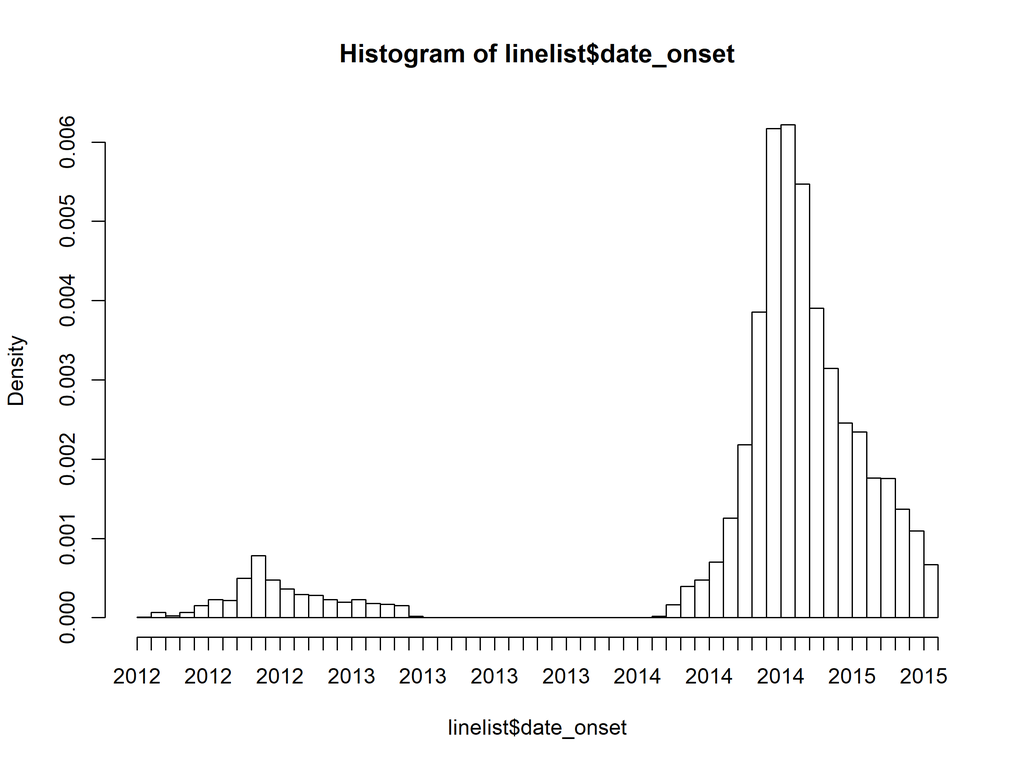

```r
hist(linelist$date_onset, breaks = 50)
```

#### How filters handle missing numeric and date values

Can we just filter by `date_onset` to rows after June 2013? **Caution! Applying the code `filter(date_onset > as.Date("2013-06-01")))` would accidentally remove any rows in the later epidemic with a missing date of onset!**

*DANGER:* Filtering to greater than (>) or less than (<) a date or number can remove any rows with missing values (`NA`)! This is because `NA` is treated as infinitely large and small.

#### Design the filter

Examine a cross-tabulation to make sure we exclude only the correct rows:

```r
table(Hospital  = linelist$hospital,                     # hospital name
      YearOnset = lubridate::year(linelist$date_onset),  # year of date_onset
      useNA     = "always")                              # show missing values
##                                       YearOnset
## Hospital                               2012 2013 2014 2015 <NA>
##   Central Hospital                        0    0  334   94   26
##   Hospital A                            214   67    0    0    8
##   Hospital B                            212   69    0    0    8
##   Military Hospital                       0    0  662  194   40
##   Missing                                 0    0 1111  301   57
##   Other                                   0    0  678  171   36
##   Port Hospital                           7    3 1358  330   74
##   St. Mark's Maternity Hospital (SMMH)    0    0  319   89   14
##   <NA>                                    0    0    0    0    0
```

What other criteria can we filter on to remove the first outbreak from the dataset? We see that:

- The first epidemic occurred at Hospital A, Hospital B, and that there were also 10 cases at Port Hospital.
- Hospitals A & B did *not* have cases in the second epidemic, but Port Hospital did.

```r
linelist <- linelist %>%
  # keep rows where onset is after 1 June 2013 OR where onset is missing and it was a hospital OTHER than Hospital A or B
  filter(date_onset > as.Date("2013-06-01") | (is.na(date_onset) & !hospital %in% c("Hospital A", "Hospital B")))

nrow(linelist)
## [1] 5888
```

When we re-make the cross-tabulation, we see that Hospitals A & B are removed completely, and the 10 Port Hospital cases from 2012 & 2013 are removed, and all other values are the same - just as we wanted.

```r
table(Hospital  = linelist$hospital,                     # hospital name
      YearOnset = lubridate::year(linelist$date_onset),  # year of date_onset
      useNA     = "always")                              # show missing values
##                                       YearOnset
## Hospital                               2014 2015 <NA>
##   Central Hospital                      334   94   26
##   Military Hospital                     662  194   40
##   Missing                              1111  301   57
##   Other                                 678  171   36
##   Port Hospital                        1358  330   74
##   St. Mark's Maternity Hospital (SMMH)  319   89   14
##   <NA>                                    0    0    0
```

Multiple statements can be included within one filter command (separated by commas), or you can always pipe to a separate filter() command for clarity.

*Note: some readers may notice that it would be easier to just filter by `date_hospitalisation` because it is 100% complete. This is true. But for p`date_onset` is used for purposes of a complex filter example.*

### Filter as a stand-alone command

### Filter as a stand-alone command

Filtering can also be done as a stand-alone command (not part of a pipe chain). Like other **dplyr** verbs, in this case the first argument must be the dataset itself.

```r
# dataframe <- filter(dataframe, condition(s) for rows to keep)

linelist <- filter(linelist, !is.na(case_id))
```

You can also use **base** R to subset using square brackets which reflect the [rows, columns] that you want to retain.

```r
# dataframe <- dataframe[row conditions, column conditions] (blank means keep all)

linelist <- linelist[!is.na(case_id), ]
```

*TIP:* Use bracket-subset syntax with `View()` to quickly review a few records.

### Filtering to quickly review data

### Filtering to quickly review data

This **base** R syntax can be handy when you want to quickly view a subset of rows and columns. Use the **base** R `View()` command (note the capital “V”) around the [] subset you want to see. The result will appear as a dataframe in your RStudio viewer panel. For example, if I want to review onset and hospitalization dates of 3 specific cases:

View the linelist in the viewer panel:

```r
View(linelist)
```

View specific data for three cases:

```r
View(linelist[linelist$case_id %in% c("11f8ea", "76b97a", "47a5f5"), c("date_onset", "date_hospitalisation")])
```

Note: the above command can also be written with **dplyr** verbs `filter()` and `select()` as below:

```r
View(linelist %>%
       filter(case_id %in% c("11f8ea", "76b97a", "47a5f5")) %>%
       select(date_onset, date_hospitalisation))
```

### Add to pipe chain

### Add to pipe chain

```r
# CLEANING 'PIPE' CHAIN (starts with raw data and pipes it through cleaning steps)
##################################################################################

# begin cleaning pipe chain
###########################
linelist <- linelist_raw %>%

    # standardize column name syntax
    janitor::clean_names() %>%

    # manually re-name columns
           # NEW name             # OLD name
    rename(date_infection       = infection_date,
           date_hospitalisation = hosp_date,
           date_outcome         = date_of_outcome) %>%

    # remove column
        select(-c(row_num, merged_header, x24)) %>%

    # fix incorrect values                 # old value       # new value
    mutate(date_onset = recode(date_onset, "15th April 2014" = "2014-04-15")) %>%

    # correct the class of the columns
    mutate(across(contains("date"), as.Date),
           generation = as.numeric(generation),
           age        = as.numeric(age)) %>%

    # clean values of hospital column
    mutate(hospital = recode(hospital,
                      # OLD = NEW
                      "Mitylira Hopital"  = "Military Hospital",
                      "Mitylira Hospital" = "Military Hospital",
                      "Military Hopital"  = "Military Hospital",
                      "Port Hopital"      = "Port Hospital",
                      "Central Hopital"   = "Central Hospital",
                      "other"             = "Other",
                      "St. Marks Maternity Hopital (SMMH)" = "St. Mark's Maternity Hospital (SMMH)"
                      )) %>%

    mutate(hospital = replace_na(hospital, "Missing")) %>%

    # create age_years column (from age and age_unit)
    mutate(age_years = case_when(
          age_unit == "years"  ~ age,
          age_unit == "months" ~ age/12,
          is.na(age_unit)      ~ age,
          TRUE                 ~ NA_real_)) %>%

  # ABOVE ARE UPSTREAM CLEANING STEPS ALREADY DISCUSSED
    ###################################################
    filter(
          # keep only rows where case_id is not missing
          !is.na(case_id),

          # also filter to keep only the second outbreak
          date_onset > as.Date("2013-06-01") | (is.na(date_onset) & !hospital %in% c("Hospital A", "Hospital B")))
```

## Numeric categories

## Numeric categories

*CAUTION:* This tab may follow from previous tabs.

Special approaches for creating numeric categories

Common examples include age categories, groups of lab values, etc.

There are several ways to create categories of a numeric column such as age. Here we will discuss:

- `age_categories()`, from the **epikit** package
- `cut()`, from **base** R
- using percentiles to break your numbers
- natural break points… ? TO DO
- case_when()

Sometimes, numeric variables will import as class “character”. This occurs if there are non-numeric characters in some of the values, for example an entry of “2 months” for age, or (depending on your R locale settings) if a comma is used in the decimals place (e.g. “4,5” to mean four and one half years).

For this example we will create an `age_cat` column using the `age_years` column.

```r
#check the class of the linelist variable age
class(linelist$age_years)
## [1] "numeric"
```

### `age_categories()`**

### `age_categories()`

With the **epikit** package, you can use the `age_categories()` function to easily categorize and label numeric columns (note: this can be applied to non-age numeric variables too). The output is an ordered factor.

The break values specified are included in the higher group, that is groups are open on the lower/left side. As shown below, you can add 1 to each break value to achieve groups that are open at the top/right.

Other *optional* arguments:

- `lower =` Default is 0). The lowest number you want considered.
- `upper =` The highest number you want considered.
- `by =` The number of years between groups.
- `separator =` Default is “-”. Character between ages in labels.
- `ceiling =` Default FALSE. If TRUE, the highest break value is a ceiling and a category “XX+” is not included. Any values above highest break or `upper` (if defined) are categorized as `NA`.

See the function’s Help page for more details (enter `?age_categories` in the R console).

```r
library(epikit)

# Simple example
################
linelist <- linelist %>%
  mutate(age_cat = age_categories(age_years,
                                  breakers = c(0, 5, 10, 15, 20, 30, 50, 70)))
# show table
table(linelist$age_cat, useNA = "always")
##
##   0-4   5-9 10-14 15-19 20-29 30-49 50-69   70+  <NA>
##  1110  1101   999   826  1148   575    42     0    87


# With ceiling set to TRUE
##########################
linelist <- linelist %>%
  mutate(age_cat = age_categories(age_years,
                                  breakers = c(0, 5, 10, 15, 20, 30, 50, 70),
                                  upper = max(linelist$age_years, na.rm=T),
                                  ceiling = TRUE)) # 70 is the ceiling
# show table
table(linelist$age_cat, useNA = "always")
##
##   0-4   5-9 10-14 15-19 20-29 30-49 50-70  <NA>
##  1110  1101   999   826  1148   575    42    87


# Include upper ends for the same categories
############################################
linelist <- linelist %>%
  mutate(age_cat = age_categories(age_years,
                                  upper = max(linelist$age_years, na.rm=T),
                                  breakers = c(0, 6, 11, 16, 21, 31, 51, 71, 76)))
# show table
table(linelist$age_cat, useNA = "always")
##
##   0-5  6-10 11-15 16-20 21-30 31-50 51-70 71-75   76+  <NA>
##  1320  1107   951   801  1072   513    37     0     0    87
```

### `cut()`

### `cut()`

You can use the **base** R function `cut()`, which creates categories from a numeric variable. The differences from `age_categories()` are:

- You do not need to install/load another package
- You can specify whether groups are open/closed on the right/left
- You must provide labels yourself (and ensure they are accurate to the groups)
- If you want 0 included in the lowest group you must specify this

The basic syntax within `cut()` is to first provide the numeric variable to be cut (age_years), and then the *breaks* argument, which is a numeric vector (`c()`) of break points. Using `cut()`, the resulting column is an ordered factor.

If used within `mutate()` (a **dplyr** verb) it is not necessary to specify the dataframe before the column name (e.g. `linelist$age_years`).

#### Simple `cut()` example

### Simple `cut()` example

- Specify numeric vector of break points `c(0, 5, 10, 15, ...)`
- Default behavior for `cut()` is that lower break values are *excluded* from each category, and upper break values are *included*. This is the opposite behavior from the `age_categories()` function.
- Include 0 in the lowest category by adding `include.lowest = TRUE`
- Add a vector of customized labels using the `labels =` argument
- Check your work with cross-tabulation of the numeric and category columns - be aware of missing values

```r
linelist <- linelist %>%
  mutate(age_cat = cut(age_years,                                       # numeric column
                        breaks = c(0, 5, 10, 15, 20, 30, 50, 70,        # break points...
                                   max(linelist$age_years, na.rm=T)),   # ... with dynamic last break as column max value
                        right = TRUE,                                   # lower breaks included and upper excluded [a,b)
                        include.lowest = TRUE,                          # 0 included in lowest category
                        labels = c("0-4", "5-9", "10-14", "15-19",      # manual labels - be careful!
                                   "20-29", "30-49", "50-69", "70+")))

table(linelist$age_cat, useNA = "always")
##
##   0-4   5-9 10-14 15-19 20-29 30-49 50-69   70+  <NA>
##  1320  1107   951   801  1072   513    37     0    87
```

#### `cut()` details

### `cut()` details

Below is a detailed description of the behavior of using `cut()` to make the `age_cat` column. Key points:

- Inclusion/exclusion behavior of break points
- Custom category labels
- Handling missing values
- **Check your work!**

The most simple command of `cut()` applied to `age_years` to make the new variable `age_cat` is below:

```r
# Create new variable, by cutting the numeric age variable
# by default, upper break is excluded and lower break excluded from each category
linelist <- linelist %>%
  mutate(age_cat = cut(age_years, breaks = c(0, 5, 10, 15, 20, 30, 50, 70, 100)))

# tabulate the number of observations per group
table(linelist$age_cat, useNA = "always")
##
##    (0,5]   (5,10]  (10,15]  (15,20]  (20,30]  (30,50]  (50,70] (70,100]
##     1206     1107      951      801     1072      513       37        0
##     <NA>
##      201
```

```r
# Cross tabulation of the numeric and category columns.
table("Numeric Values" = linelist$age_years,   # names specified in table for clarity.
      "Categories"     = linelist$age_cat,
      useNA = "always")                        # don't forget to examine NA values
##                     Categories
## Numeric Values       (0,5] (5,10] (10,15] (15,20] (20,30] (30,50] (50,70]
##   0                      0      0       0       0       0       0       0
##   0.0833333333333333     2      0       0       0       0       0       0
##   0.166666666666667      5      0       0       0       0       0       0
##   0.25                   2      0       0       0       0       0       0
##   0.333333333333333      1      0       0       0       0       0       0
##   0.416666666666667      2      0       0       0       0       0       0
##   0.5                    1      0       0       0       0       0       0
##   0.583333333333333      2      0       0       0       0       0       0
##   0.666666666666667      1      0       0       0       0       0       0
##   0.75                   3      0       0       0       0       0       0
##   0.916666666666667      1      0       0       0       0       0       0
##   1                    254      0       0       0       0       0       0
##   1.5                    3      0       0       0       0       0       0
##   2                    242      0       0       0       0       0       0
##   3                    231      0       0       0       0       0       0
##   4                    246      0       0       0       0       0       0
##   5                    210      0       0       0       0       0       0
##   6                      0    227       0       0       0       0       0
##   7                      0    215       0       0       0       0       0
##   8                      0    212       0       0       0       0       0
##   9                      0    237       0       0       0       0       0
##   10                     0    216       0       0       0       0       0
##   11                     0      0     191       0       0       0       0
##   12                     0      0     194       0       0       0       0
##   13                     0      0     207       0       0       0       0
##   14                     0      0     191       0       0       0       0
##   15                     0      0     168       0       0       0       0
##   16                     0      0       0     181       0       0       0
##   17                     0      0       0     156       0       0       0
##   18                     0      0       0     148       0       0       0
##   19                     0      0       0     173       0       0       0
##   20                     0      0       0     143       0       0       0
##   21                     0      0       0       0     139       0       0
##   22                     0      0       0       0     133       0       0
##   23                     0      0       0       0     144       0       0
##   24                     0      0       0       0     106       0       0
##   25                     0      0       0       0      99       0       0
##   26                     0      0       0       0     122       0       0
##   27                     0      0       0       0     105       0       0
##   28                     0      0       0       0      87       0       0
##   29                     0      0       0       0      70       0       0
##   30                     0      0       0       0      67       0       0
##   31                     0      0       0       0       0      70       0
##   32                     0      0       0       0       0      56       0
##   33                     0      0       0       0       0      65       0
##   34                     0      0       0       0       0      36       0
##   35                     0      0       0       0       0      46       0
##   36                     0      0       0       0       0      34       0
##   37                     0      0       0       0       0      18       0
##   38                     0      0       0       0       0      25       0
##   39                     0      0       0       0       0      29       0
##   40                     0      0       0       0       0      19       0
##   41                     0      0       0       0       0      19       0
##   42                     0      0       0       0       0      21       0
##   43                     0      0       0       0       0      13       0
##   44                     0      0       0       0       0      14       0
##   45                     0      0       0       0       0      15       0
##   46                     0      0       0       0       0       4       0
##   47                     0      0       0       0       0       7       0
##   48                     0      0       0       0       0       9       0
##   49                     0      0       0       0       0       8       0
##   50                     0      0       0       0       0       5       0
##   51                     0      0       0       0       0       0       4
##   52                     0      0       0       0       0       0       3
##   53                     0      0       0       0       0       0       8
##   54                     0      0       0       0       0       0       4
##   55                     0      0       0       0       0       0       4
##   56                     0      0       0       0       0       0       4
##   58                     0      0       0       0       0       0       2
##   59                     0      0       0       0       0       0       1
##   60                     0      0       0       0       0       0       2
##   61                     0      0       0       0       0       0       1
##   63                     0      0       0       0       0       0       1
##   64                     0      0       0       0       0       0       2
##   67                     0      0       0       0       0       0       1
##   <NA>                   0      0       0       0       0       0       0
##                     Categories
## Numeric Values       (70,100] <NA>
##   0                         0  114
##   0.0833333333333333        0    0
##   0.166666666666667         0    0
##   0.25                      0    0
##   0.333333333333333         0    0
##   0.416666666666667         0    0
##   0.5                       0    0
##   0.583333333333333         0    0
##   0.666666666666667         0    0
##   0.75                      0    0
##   0.916666666666667         0    0
##   1                         0    0
##   1.5                       0    0
##   2                         0    0
##   3                         0    0
##   4                         0    0
##   5                         0    0
##   6                         0    0
##   7                         0    0
##   8                         0    0
##   9                         0    0
##   10                        0    0
##   11                        0    0
##   12                        0    0
##   13                        0    0
##   14                        0    0
##   15                        0    0
##   16                        0    0
##   17                        0    0
##   18                        0    0
##   19                        0    0
##   20                        0    0
##   21                        0    0
##   22                        0    0
##   23                        0    0
##   24                        0    0
##   25                        0    0
##   26                        0    0
##   27                        0    0
##   28                        0    0
##   29                        0    0
##   30                        0    0
##   31                        0    0
##   32                        0    0
##   33                        0    0
##   34                        0    0
##   35                        0    0
##   36                        0    0
##   37                        0    0
##   38                        0    0
##   39                        0    0
##   40                        0    0
##   41                        0    0
##   42                        0    0
##   43                        0    0
##   44                        0    0
##   45                        0    0
##   46                        0    0
##   47                        0    0
##   48                        0    0
##   49                        0    0
##   50                        0    0
##   51                        0    0
##   52                        0    0
##   53                        0    0
##   54                        0    0
##   55                        0    0
##   56                        0    0
##   58                        0    0
##   59                        0    0
##   60                        0    0
##   61                        0    0
##   63                        0    0
##   64                        0    0
##   67                        0    0
##   <NA>                      0   87
```

Read more about `cut()` in its Help page by entering `?cut` in the R console.

**Reversing break inclusion behavior in `cut()`**

```r
linelist <- linelist %>%
  mutate(age_cat = cut(age_years,
                          breaks = c(0, 5, 10, 15, 20, 30, 50, 70, 100),     # same breaks
                          right = FALSE,                                     # include each *lower* break point
                          labels = c("0-4", "5-9", "10-14", "15-19",
                                     "20-29", "30-49", "50-69", "70-100")))  # now the labels must change

table(linelist$age_cat, useNA = "always")
##
##    0-4    5-9  10-14  15-19  20-29  30-49  50-69 70-100   <NA>
##   1110   1101    999    826   1148    575     42      0     87
```

**Re-labeling `NA` values with `cut()`**

Because `cut()` does not automatically label `NA` values, you may want to assign a label such as “Missing”. This requires a few extra steps because `cut()` automatically classified the new column `age_cat` as a Factor (a rigid column class with specific value labels).

First, convert `age_cut` from Factor to Character class, so you have flexibility to add new character values (e.g. “Missing”). Otherwise you will encounter an error. Then, use the **dplyr** verb `replace_na()` to replace `NA` values with a character value like “Missing”. These steps can be combined into one step, as shown below.

Note that Missing has been added, **but the order of the categories is now wrong (alphabetical).**

```r
linelist <- linelist %>%

  # cut() creates age_cat, automatically of class Factor
  mutate(age_cat = cut(age_years,
                          breaks = c(0, 5, 10, 15, 20, 30, 50, 70, 100),
                          right = FALSE,
                          labels = c("0-4", "5-9", "10-14", "15-19",
                                     "20-29", "30-49", "50-69", "70-100")),

         # convert to class Character, and replace NA with "Missing"
         age_cat = replace_na(as.character(age_cat), "Missing"))


table(linelist$age_cat, useNA = "always")
##
##     0-4   10-14   15-19   20-29   30-49     5-9   50-69 Missing    <NA>
##    1110     999     826    1148     575    1101      42      87       0
```

To fix this, re-convert `age_cat` to a factor, and define the order of the levels correctly.

```r
linelist <- linelist %>%

  # cut() creates age_cat, automatically of class Factor
  mutate(age_cat = cut(age_years,
                          breaks = c(0, 5, 10, 15, 20, 30, 50, 70, 100),
                          right = FALSE,
                          labels = c("0-4", "5-9", "10-14", "15-19",
                                     "20-29", "30-49", "50-69", "70-100")),

         # convert to class Character, and replace NA with "Missing"
         age_cat = replace_na(as.character(age_cat), "Missing"),

         # re-classify age_cat as Factor, with correct level order and new "Missing" level
         age_cat = factor(age_cat, levels = c("0-4", "5-9", "10-14", "15-19", "20-29",
                                              "30-49", "50-69", "70-100", "Missing")))


table(linelist$age_cat, useNA = "always")
##
##     0-4     5-9   10-14   15-19   20-29   30-49   50-69  70-100 Missing    <NA>
##    1110    1101     999     826    1148     575      42       0      87       0
```

If you want a fast way to make breaks and labels, you can use something like below (adjust to your specific situation). See the page on using seq() and rep() and c() TO DO

```r
# Make break points from 0 to 90 by 5
age_seq = seq(from = 0, to = 90, by = 5)
age_seq

# Make labels for the above categories, assuming default cut() settings
age_labels = paste0(age_seq+1, "-", age_seq + 5)
age_labels

# check that both vectors are the same length
length(age_seq) == length(age_labels)

# # Use them in the cut() command
# cut(linelist$age, breaks = age_seq, labels = age_labels)
```

### `case_when()`

### `case_when()`

The dplyr function `case_when()` can also be used to create numeric categories.

- Allows explicit setting of break point inclusion/exclusion
- Allows designation of label for `NA` values in one step
- More complicated code, *arguably* more prone to error
- Allow more flexibility to include other variables in the logic

**If using `case_when()` please review the in-depth page on it, as the logic and order of assignment are important understand to avoid errors.**

*CAUTION:* In `case_when()` all right-hand side values must be of the same class. Thus, if your categories are character values (e.g. “20-30 years”) then any designated outcome for `NA` age values must also be character (“Missing”, or the special `NA_character_` instead of `NA`).

You will need to designate the column as a factor (by wrapping `case_when()` in the function `factor()`) and provide the ordering of the factor levels using the `levels =` argument *after* the close of the `case_when()` function. When using `cut()`, the factor and ordering of levels is done automatically.

```r
linelist <- linelist %>%
  mutate(age_cat = factor(case_when(
          # provide the case_when logic and outcomes
          age_years >= 0 & age_years < 5     ~ "0-4",          # logic by age_year value
          age_years >= 5 & age_years < 10    ~ "5-9",
          age_years >= 10 & age_years < 15   ~ "10-14",
          age_years >= 15 & age_years < 20   ~ "15-19",
          age_years >= 20 & age_years < 30   ~ "20-29",
          age_years >= 30 & age_years < 50   ~ "30-49",
          age_years >= 50 & age_years < 70   ~ "50-69",
          age_years >= 45 & age_years <= 100 ~ "70-100",
          is.na(age_years)                   ~ "Missing",  # if age_years is missing
          TRUE                               ~ "Check value"   # catch-all alarm to trigger review
          ), levels = c("0-4","5-9", "10-14", "15-19", "20-29", "30-49", "50-69", "70-100", "Missing", "Check value"))
         )


table(linelist$age_cat, useNA = "always")
##
##         0-4         5-9       10-14       15-19       20-29       30-49
##        1110        1101         999         826        1148         575
##       50-69      70-100     Missing Check value        <NA>
##          42           0          87           0           0
```

### Add to pipe chain

### Add to pipe chain

Below, code to create two categorical age columns is added to the cleaning pipe chain:

```r
# CLEANING 'PIPE' CHAIN (starts with raw data and pipes it through cleaning steps)
##################################################################################

# begin cleaning pipe chain
###########################
linelist <- linelist_raw %>%

    # standardize column name syntax
    janitor::clean_names() %>%

    # manually re-name columns
           # NEW name             # OLD name
    rename(date_infection       = infection_date,
           date_hospitalisation = hosp_date,
           date_outcome         = date_of_outcome) %>%

    # remove column
        select(-c(row_num, merged_header, x24)) %>%

    # fix incorrect values                 # old value       # new value
    mutate(date_onset = recode(date_onset, "15th April 2014" = "2014-04-15")) %>%

    # correct the class of the columns
    mutate(across(contains("date"), as.Date),
           generation = as.numeric(generation),
           age        = as.numeric(age)) %>%

    # clean values of hospital column
    mutate(hospital = recode(hospital,
                      # OLD = NEW
                      "Mitylira Hopital"  = "Military Hospital",
                      "Mitylira Hospital" = "Military Hospital",
                      "Military Hopital"  = "Military Hospital",
                      "Port Hopital"      = "Port Hospital",
                      "Central Hopital"   = "Central Hospital",
                      "other"             = "Other",
                      "St. Marks Maternity Hopital (SMMH)" = "St. Mark's Maternity Hospital (SMMH)"
                      )) %>%

    mutate(hospital = replace_na(hospital, "Missing")) %>%

    # create age_years column (from age and age_unit)
    mutate(age_years = case_when(
          age_unit == "years" ~ age,
          age_unit == "months" ~ age/12,
          is.na(age_unit) ~ age,
          TRUE ~ NA_real_)) %>%

    filter(
          # keep only rows where case_id is not missing
          !is.na(case_id),

          # also filter to keep only the second outbreak
          date_onset > as.Date("2013-06-01") | (is.na(date_onset) & !hospital %in% c("Hospital A", "Hospital B"))) %>%

    # ABOVE ARE UPSTREAM CLEANING STEPS ALREADY DISCUSSED
    ###################################################
    mutate(
          # age categories: custom
          age_cat = epikit::age_categories(age_years, breakers = c(0, 5, 10, 15, 20, 30, 50, 70)),

          # age categories: 0 to 85 by 5s
          age_cat5 = epikit::age_categories(age_years, breakers = seq(0, 85, 5)))
```

## rowwise() **dplyr()**

## rowwise() **dplyr**

https://cran.r-project.org/web/packages/dplyr/vignettes/rowwise.html

```r
linelist <- linelist %>%
  rowwise() %>%
  mutate(num_symptoms = sum(c(fever, chills, cough, aches, vomit) == "yes"))
```

## Transforming multiple variables at once

## Transforming multiple variables at once

*CAUTION:* This tab may follow from previous tabs.

A transformation can be applied to multiple variables at once using the `across()` function from the package **dplyr** (contained within **tidyverse** package).

`across()` can be used with any **dplyr** verb, but commonly with as `mutate()`, `filter()`, or `summarise()`. Here are some examples to get started.

Example of how one would change all columns to character class

```r
#to change all columns to character class
linelist <- linelist %>%
  mutate(across(everything(), as.character))
```

Here are a few online resources on using `across()`: [Hadley Wickham’s thoughts/rationale](https://www.tidyverse.org/blog/2020/04/dplyr-1-0-0-colwise/)

## Deduplication

## Deduplication

*CAUTION:* This tab may follow from previous tabs.

The package **dplyr** offers the `distinct()` function to reduce the dataframe to only unique rows - removing duplicates.  
In this case we just want to remove rows that are complete duplicates, so we just add the simple command `distinct()`.

For more complex deduplications see the page on deduplicating.

We begin with 5888 rows in `linelist`.

```r
linelist <- linelist %>%
  distinct()
```

After deduplication there are 5888 rows.

Below, the `distinct()` command is added to the cleaning pipe chain:

```r
# CLEANING 'PIPE' CHAIN (starts with raw data and pipes it through cleaning steps)
##################################################################################

# begin cleaning pipe chain
###########################
linelist <- linelist_raw %>%

    # standardize column name syntax
    janitor::clean_names() %>%

    # manually re-name columns
           # NEW name             # OLD name
    rename(date_infection       = infection_date,
           date_hospitalisation = hosp_date,
           date_outcome         = date_of_outcome) %>%

    # remove column
        select(-c(row_num, merged_header, x24)) %>%

    # fix incorrect values                 # old value       # new value
    mutate(date_onset = recode(date_onset, "15th April 2014" = "2014-04-15")) %>%

    # correct the class of the columns
    mutate(across(contains("date"), as.Date),
           generation = as.numeric(generation),
           age        = as.numeric(age)) %>%

    # clean values of hospital column
    mutate(hospital = recode(hospital,
                      # OLD = NEW
                      "Mitylira Hopital"  = "Military Hospital",
                      "Mitylira Hospital" = "Military Hospital",
                      "Military Hopital"  = "Military Hospital",
                      "Port Hopital"      = "Port Hospital",
                      "Central Hopital"   = "Central Hospital",
                      "other"             = "Other",
                      "St. Marks Maternity Hopital (SMMH)" = "St. Mark's Maternity Hospital (SMMH)"
                      )) %>%

    mutate(hospital = replace_na(hospital, "Missing")) %>%

    # create age_years column (from age and age_unit)
    mutate(age_years = case_when(
          age_unit == "years" ~ age,
          age_unit == "months" ~ age/12,
          is.na(age_unit) ~ age,
          TRUE ~ NA_real_)) %>%

    filter(
          # keep only rows where case_id is not missing
          !is.na(case_id),

          # also filter to keep only the second outbreak
          date_onset > as.Date("2013-06-01") | (is.na(date_onset) & !hospital %in% c("Hospital A", "Hospital B"))) %>%

    mutate(
          # age categories: custom
          age_cat = epikit::age_categories(age_years, breakers = c(0, 5, 10, 15, 20, 30, 50, 70)),

          # age categories: 0 to 85 by 5s
          age_cat5 = epikit::age_categories(age_years, breakers = seq(0, 85, 5))) %>%

    distinct()
```